```python
from platform import python_version

print(python_version())
```

```
3.7.6
```

```python
#Import library
from IPython.display import Image
```

# I/O - Python Input/Output

- #### In Python, we have two built-in functions `print() and input()` to perform I/O task in Python.
- `input()` and `print()` are widely used for `standard input` and `output` operations respectively.

## Python Output Using print() function

```python
print("Hello! World, Practicing Python.")
```

```
Hello! World, Practicing Python.
```

```python
a = 5
print('The value of `a` is ', a)
```

```
The value of `a` is  5
```

**In the second print() statement, we can notice that space was added between the string and the value of variable a. This is by default, but we can change it.**

**>>> Actual syntax of print():**

**`print(*objects, sep=' ', end='\n', file=sys.stdout, flush=False)`**

> - `objects` are the values to be printed.
> - `sep` separator is used between the values. It defaults into a **space character.**
> - After all values are printed, `end` is printed. It defaults into a **new line.**
> - The `file` is the object where the values are printed and its default value is **sys.stdout (screen)**.

**>>>Example to illustrate this.**

```python
print(1, 2, 3, 4)
print(1, 2, 3, 4, sep='*')
print(1, 2, 3, 4, sep='#', end='&')
```

```
1 2 3 4
1*2*3*4
1#2#3#4&
```

### end = * in print()

```python
j = ["Hello!", "World,", "Practicing", "Python."]
for i in j:
    print(i)
```

```
Hello!
World,
Practicing
Python.
```

### default value for end = * is '\n' - New Line

```python
j = ["Hello!", "World,", "Practicing", "Python."]
for i in j:
    print(i, end = '\n')
```

```
Hello!
World,
Practicing
Python.
```

## Other Ways we Can Use

```python
j = ["Hello!", "World,", "Practicing", "Python."]
for i in j:
    print(i, end = ' ')
```

```
Hello! World, Practicing Python.
```

```python
j = ["Hello!", "World,", "Practicing", "Python."]
for i in j:
    print(i, end = '-')
```

```
Hello!-World,-Practicing-Python.-
```

```python
j = ["Hello!", "World,", "Practicing", "Python."]
j = ["Hello!", "World,", "Practicing", "Python."]
j = ["Hello!", "World,", "Practicing", "Python."]
for i in j:
    print(i, end = '+')
```

```
Hello!+World,+Practicing+Python.+
```

## Output formatting

Sometimes we would like to format our output to make it look attractive. This can be done by using the str.format() method. This method is visible to any string object.

```python
x = 5; y = 10
print('The value of x is {} and y is {}'.format(x,y))
print('I love {0} and {1}'.format('bread','butter'))
print('I love {1} and {0}'.format('bread','butter'))
```

```
The value of x is 5 and y is 10
I love bread and butter
I love butter and bread
```

- We can even use keyword arguments to format the string.

```python
print('Hello {name}, {greeting}'.format(greeting = 'Goodmorning', name = 'John'))
```

```
Hello John, Goodmorning
```

#### We can also format strings like the old sprintf() style used in C programming language. We use the % operator to accomplish this.

```python
x = 1212.3456789

print('The value of x is %d' %x)

print('The value of x is %.2f' %x) # two digits after decimal point

print('The value of x is %.4f' %x) # four digits after decimal point
```

```
The value of x is 1212
The value of x is 1212.35
The value of x is 1212.3457
```

# Python Input

### Reading Input from Keyboard

```python
x = input('Enter a 3 digit number: ')
```

```
Enter a 3 digit number: 123
```

```python
x
```

```
'123'
```

```python
type(x)
```

```
str
```

- **Anything entered as input is by default taken as string type.**
- **To convert this into a number we can use int() or float() functions.** (Type Casting we will discuss in detail later.)

```python
int(x)
```

```
123
```

```python
float(x)
```

```
123.0
```

## eval()

The same operation can be performed using the **`eval()`** function. But **eval** takes it further. It can evaluate even expressions, provided the input is a string.

```python
x = input('Add 2 and 3 : ')
print(x, '\n')
print(type(x), '\n')
int(x)
```

```
Add 2 and 3 : 2+3
2+3

<class 'str'>
```

```
---------------------------------------------------------------------------
ValueError                                Traceback (most recent call last)
<ipython-input-19-97f65b3dbab0> in <module>
      2 print(x, '\n')
      3 print(type(x), '\n')
----> 4 int(x)

ValueError: invalid literal for int() with base 10: '2+3'
```

```python
eval(x) #eval('2+3')
```

```
5
```

# Python Basic Syntax

- **Python Identifiers**
  - A Python identifier is a name used to identify a variable, function, class, module or other object.
  - An identifier **starts with a letter *A to Z or a to z or an underscore ( _ ) followed by zero or more letters, underscores and digits (0 to 9)***.
  - Python **does not allow punctuation characters such as @, $, and % within identifiers.**
  - Python is a **case sensitive programming language**.
    - *Thus, **Manpower** and **manpower** are two different identifiers in Python.*
- **Here are naming conventions for Python identifiers.**
  - *Class names start with an **uppercase letter.** All **other identifiers start with a lowercase letter.***
  - Starting an identifier with a single leading underscore indicates that the identifier is private.
  - Starting an identifier with two leading underscores indicates a strongprivate identifier.
  - If the identifier also ends with two trailing underscores, the identifier is a language-defined special name.

## Reserved Words

- The following list shows the **Python keywords**.
  - These are **reserved words and you cannot use them as constants or variables or any other identifier names**.
  - **In Python, keywords are case sensitive.**
  - **All the Python keywords contain lowercase letters except `True`, `False` and `None`.**

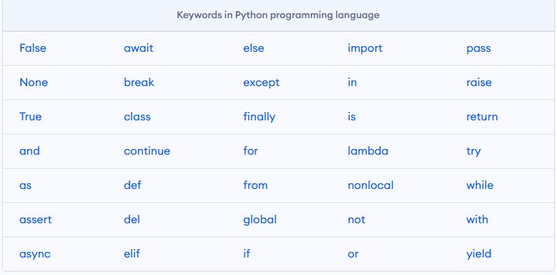

```python
Image('keywords.JPG', width = 900, height = 900)
```

### List of all keywords with examples.

```python
link = "https://www.programiz.com/python-programming/keyword-list"

print("For detailed description of Keywords purpose with examples, click here : ", link)
```

```
For detailed description of Keywords purpose with examples, click here :  https://www.programiz.com/python-programming/keyword-list
```

## Lines and Indentation

- Blocks of code are denoted by line indentation, which is rigidly enforced.

  ```
  Example
  ```

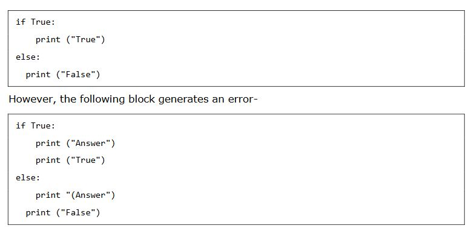

```python
Image('eg_indentation.JPG', width = 800, height = 1200)
```

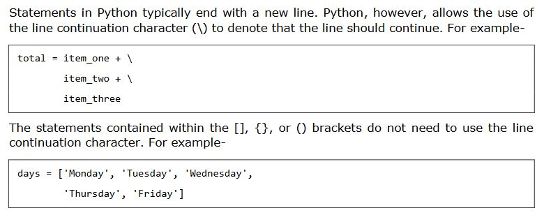

```python
Image('Multiline.JPG', width = 800, height = 900)
```

## Multiple Statements on a Single Line

- The semicolon ( ; ) allows multiple statements on asingle line given that no statement starts a new code block.
  - Here is a sample snip using the semicolon

```python
import sys; x ='foo'; sys.stdout.write(x +'\n')
```

```
foo
```

## Multiple Statement Groups as Suites

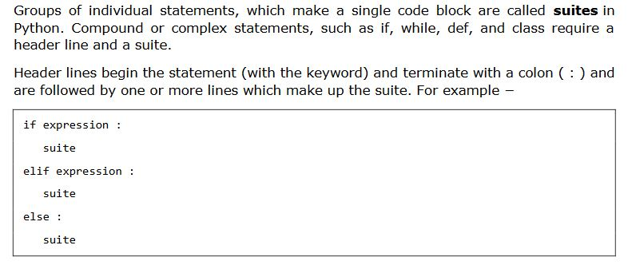

```python
Image('suites.JPG', width = 800, height = 900)
```